# A study on $CO_2$ emissions produced by automotive vehicles

### *09/03/2021 - Fabrizio Boffa*

## 1. Data

For this study our source of data is the United States Environmental Protection Agency (EPA).  
EPA's National Vehicle and Fuel Emissions Laboratory tests new cars and trucks sold in the U.S. to ensure that they comply with federal emissions and fuel economy standards. The dataset is updated weekly and we will use the last update available at the date.  
At the end of this study we will dedicate a paragraph about the quality of the used data while now we will proceed straight to the data acquisition process.

We will import these categorical features:

- **VClass** = EPA vehicle size class
- **make** = manufacturer (division)
- **drive** = drive axle type
- **fuelType1** = primary fuel type. For single fuel vehicles, this will be the only fuel. For dual fuel vehicles, this will be the conventional fuel.
- **fuelType2** = secondary fuel type. For dual fuel vehicles, this will be the alternative fuel (e.g. E85, Electricity, CNG, LPG).
- **tCharger** = if T, the vehicle is turbocharged
- **sCharger** = if S, the vehicle is supercharged

and these numerical features:

- **year** = model year
- **displ** = engine displacement in liters
- **cylinders** = engine cylinders
- **co2TailpipeGpm** = tailpipe $CO_2$ emissions in grams/mile testing with fuelType1
- **co2TailpipeAGpm** = tailpipe $CO_2$ emissions in grams/mile testing with fuelType2 (if hybrid)

To define the vehicle VClass, EPA uses this segmentation:

- Two-Seaters = Any (cars designed to seat only two adults)
- Minicompact Cars = Less than 85 cu ft.
- Subcompact Cars = 85 to 99 cu ft.
- Compact Cars = 100 to 109 cu ft.
- Mid-Size Cars = 110 to 119 cu ft.
- Large Cars = 120 or more cu ft.
- Small Station Wagons = Less than 130 cu ft.
- Mid-Size Cars Station Wagons = 130 to 159 cu ft.
- Large Cars Station Wagons = 160 or more cu ft.
- Small Pickup Trucks = Less than 4,500 lbs GVWR through Model Year 2007
- Small Pickup Trucks = Less than 6,000 lbs GVWR after Model Year 2008
- Standard Pickup Trucks = 4,500 to 8,500 lbs GVWR through Model Year 2007
- Standard Pickup Trucks = 6,000 to 8,500 lbs GVWR after Model Year 2008
- Passenger Vans = Less than 8,500 lbs GVWR through Model Year 2010
- Passenger Vans = Less than 10,000 lbs GVWR beginning Model Year 2011
- Cargo Vans = Less than 8,500 lbs GVWR
- Minivans = Less than 8,500 lbs GVWR
- Sport Utility Vehicles (SUVs) = Less than 8,500 lbs GVWR through Model Year 2010
- Sport Utility Vehicles (SUVs) = Less than 10,000 lbs GVWR beginning Model Year 2011
- Small Sport Utility Vehicles (SUVs) = Less than 6,000 lbs GVWR beginning Model Year 2013
- Standard Sport Utility Vehicles (SUVs) = 6,000 to 10,000 lbs GVWR beginning Model Year 2013
- Special Purpose Vehicles = Less than 8,500 lbs GVWR through Model Year 2010
- Special Purpose Vehicles = Less than 10,000 lbs GVWR beginning Model Year 2011

*Gross Vehicle Weight Rating (GVWR) is calculated as truck weight plus carrying capacity.*

**The goal of this study is to find answers to these questions:**

- **Does Premium gasoline produce less $CO_2$ emissions than Regular?**
- **Are vehicles designed by USA manufacturers more polluting than the others?**
- **Are newer designed vehicles less polluting than older ones?**

Since the EPA dataset is not representative of the population of the vehicles in service, it's important to note that we can respond to these questions only from a technological perspective and not from a real environmental impact perspective. In other words, we could discover that newer car models are technically more ecological than older ones, but since we don't know how many new models are on the streets respect older ones we can't desume their actual impact on the environment.

For model year 2013 and beyond, tailpipe $CO_2$ emssions are based on EPA tests. For previous model years, $CO_2$ is estimated using an EPA emission factor.  
Given this, we will focus only on data relative to vehicles models from 2013 included till today.

## 2. Data exploration

Let's start data exploration looking at categorical features.

|  | VClass | make | model | drive | tCharger | sCharger | fuelType1 | fuelType2 |
| --- | --- | --- | --- | --- | --- | --- | --- | --- |
| count | 11347 | 11347 | 11347 | 11347 | 5021 | 511 | 11347 | 879 |
| unique | 22 | 59 | 2102 | 5 | 1 | 1 | 6 | 3 |
| top | Midsize Cars | BMW | Camaro | Front-Wheel Drive | T | S | Regular Gasoline | E85 |
| freq | 1756 | 943 | 69 | 3440 | 5021 | 511 | 5387 | 663 |

Let's focus now on numerical features.

The table below confirms that we have only vehicles from 2013 and beyond. We can se a median displacement value of 3.0 litres and a median number of cylinders of 6.

|  | year | displ | cylinders | co2TailpipeGpm | co2TailpipeAGpm |
| --- | --- | --- | --- | --- | --- |
| count | 11347.000000 | 11113.000000 | 11112.000000 | 11347.000000 | 11347.000000 |
| mean | 2017.025029 | 3.155584 | 5.633729 | 397.210805 | 27.261707 |
| std | 2.539150 | 1.349248 | 1.859701 | 117.577792 | 111.487123 |
| min | 2013.000000 | 0.000000 | 2.000000 | 0.000000 | 0.000000 |
| 25% | 2015.000000 | 2.000000 | 4.000000 | 332.000000 | 0.000000 |
| 50% | 2017.000000 | 3.000000 | 6.000000 | 395.000000 | 0.000000 |
| 75% | 2019.000000 | 3.700000 | 6.000000 | 466.000000 | 0.000000 |
| max | 2022.000000 | 8.400000 | 16.000000 | 893.000000 | 713.000000 |

The lists below shows, with their respective values counts, the most ten represented vehicles classes,

```
-------------------------------------------------------------------------------------------
Midsize Cars                          1756
Compact Cars                          1528
Small Sport Utility Vehicle 4WD       1142
Subcompact Cars                       1053
Large Cars                             991
Standard Sport Utility Vehicle 4WD     907
Small Sport Utility Vehicle 2WD        753
Two Seaters                            748
Minicompact Cars                       465
Small Station Wagons                   347
Name: VClass, dtype: int64
-------------------------------------------------------------------------------------------
```

the most ten represented manufacturers,

```
-------------------------------------------------------------------------------------------
BMW              943
Ford             787
Chevrolet        767
Mercedes-Benz    750
Porsche          569
Toyota           531
GMC              423
Nissan           402
Audi             399
Hyundai          377
Name: make, dtype: int64
-------------------------------------------------------------------------------------------
```

the primary fuel types

```
-------------------------------------------------------------------------------------------
Regular Gasoline     5387
Premium Gasoline     5359
Diesel                248
Electricity           235
Midgrade Gasoline     114
Natural Gas             4
Name: fuelType1, dtype: int64
-------------------------------------------------------------------------------------------
```

and the secondary fuel types.

```
-------------------------------------------------------------------------------------------
E85            663
Electricity    214
Natural Gas      2
Name: fuelType2, dtype: int64
-------------------------------------------------------------------------------------------
```

## 3. Data cleaning and feature engineering

### *3.1 Null values*

From the dataset information below, we can see we have to deal with quite many null values.

```
-------------------------------------------------------------------------------------------
<class 'pandas.core.frame.DataFrame'>
Int64Index: 11347 entries, 24380 to 37112
Data columns (total 13 columns):
 #   Column           Non-Null Count  Dtype
---  ------           --------------  -----
 0   VClass           11347 non-null  object
 1   make             11347 non-null  object
 2   model            11347 non-null  object
 3   year             11347 non-null  int64
 4   drive            11347 non-null  object
 5   displ            11113 non-null  float64
 6   cylinders        11112 non-null  float64
 7   tCharger         5021 non-null   object
 8   sCharger         511 non-null    object
 9   fuelType1        11347 non-null  object
 10  fuelType2        879 non-null    object
 11  co2TailpipeGpm   11347 non-null  float64
 12  co2TailpipeAGpm  11347 non-null  float64
dtypes: float64(4), int64(1), object(8)
memory usage: 1.2+ MB
None
-------------------------------------------------------------------------------------------
```

Let's focusing on engine displacement and number of cylinders nulls by checking if there is a reason for them to be or they are simply missing values.  
Indeed, from the check below we can see that the reason is because these vehicles have an electric engine only.

```
-------------------------------------------------------------------------------------------
Primary fuel type of vehicles with no displacement values:
Electricity    234
Name: fuelType1, dtype: int64
-------------------------------------------------------------------------------------------
Primary fuel type of vehicles with no cylinders values:
Electricity    235
Name: fuelType1, dtype: int64
-------------------------------------------------------------------------------------------
```

Since we don't want to leave them as nulls we will fill them with zeros. All in all it makes sense, since they don't have displacement and cylinders.

To take into account hybrid engines $CO_2$ emissions, we will create a new feature named **co2TailpipeGpm_comb**.  
Its value will be equal to "co2TailpipeGpm" for non hybrid vehicles and a weighted average of "co2TailpipeGpm" and "co2TailpipeAGpm" for the hybrid ones.  
As the weighting factor, we will assume that hybrid models run 70% on secondary fuel and 30% on primary.

With this last task, we have dealt with all null values that are somehow data related.  
Eventual other null values could derive only from missing values and, to clear them from the dataset, we will simply drop their entire rows.  
Below a report on how many rows with missing values have been removed.

```
-------------------------------------------------------------------------------------------
Numeber of rows with missing values removed = 0
-------------------------------------------------------------------------------------------
```

### *3.2 Outliers*

In this scenario we think that retaining outlier values during our tests is the best choice.

This conclusion comes from different considerations:

1. the source of the data is very reliable as we will see in a later paragraph of this study. This means that it's very unlikely the presence of erroneous values.
2. we will keep into account the possible outliers presence by choosing a methodology that is resistant to their effect.

As a partial confirmation of the first statement, we have checked data for the presence of really far out values. We've used the famous Tukey's fences method, based on the interquartile range:

$[Q_1 - k(Q_3 - Q_1), Q_3 + k(Q_3 - Q_1)]$

Using the values of $k$ proposed by John Tukey, the rule states that values outside that range are:

- "outlier" values, for $k = 1.5$
- "far out" values, for $k = 3$

That said, below we find the only value classifiable as a far out value.

|  | VClass | make | model | year | drive | displ | cylinders | fuelType1 | co2TailpipeGpm | charger | co2TailpipeGpm_comb |
| --- | --- | --- | --- | --- | --- | --- | --- | --- | --- | --- | --- |
| 36804 | Two Seaters | Bugatti | Chiron Pur Sport | 2021 | All-Wheel Drive | 8.0 | 16.0 | Premium Gasoline | 893.0 | Charged | 893.0 |

As we see, even in this case, the dataset proves to be reliable since the extreme value found for $CO_2$ emissions it's completely consistent with the model that produce them.

### *3.3 Utility features*

We want to engineer a new dichotomous features to quickly distinguish US models from the others.

To accomplish this task we will create a new feature that we will name "area" with two possible values: "US" and "Not US". It will quickly identify a vehicle produced by a US manufacturer if its "make" feature value is one from the list below.

```
-------------------------------------------------------------------------------------------
List of US manufacturers present in the dataframe after data cleaning:
-------------------------------------------------------------------------------------------
Chevrolet
Lincoln
Ford
Buick
Cadillac
Dodge
GMC
Roush Performance
Jeep
Chrysler
Ram
CODA Automotive
Tesla
VPG
SRT
Mobility Ventures LLC
Karma
-------------------------------------------------------------------------------------------
```

Below we show the observations count of US and non US manufacturers.

```
-------------------------------------------------------------------------------------------
Total "Not US" veichles = 7833
Total "US" veichles = 3514
-------------------------------------------------------------------------------------------
```

Finally we create also a new utility feature "age" that we will quickly separate newer from older vehicles based on year model. If before 2017 included, we will consider the vehicle as "Old", "New" differently. Below we show the observations count of "New" and "Old" vehicles.

```
-------------------------------------------------------------------------------------------
Total "Old" veichles = 6236
Total "New" veichles = 5111
-------------------------------------------------------------------------------------------
```

Since we will not need "make" and "year" features anymore, we will drop them.

Below we can see how the final dataset looks like.

|  | VClass | drive | displ | cylinders | charger | fuelType1 | area | age | co2TailpipeGpm | co2TailpipeGpm_comb |
| --- | --- | --- | --- | --- | --- | --- | --- | --- | --- | --- |
| 24380 | Subcompact Cars | All-Wheel Drive | 3.8 | 6.0 | Charged | Premium Gasoline | Not US | Old | 471.0 | 471.0 |
| 24381 | Compact Cars | Front-Wheel Drive | 2.0 | 4.0 | Charged | Premium Gasoline | Not US | Old | 349.0 | 349.0 |
| 24382 | Compact Cars | Front-Wheel Drive | 3.6 | 6.0 | Not charged | Premium Gasoline | Not US | Old | 429.0 | 429.0 |
| 24383 | Compact Cars | All-Wheel Drive | 3.6 | 6.0 | Not charged | Premium Gasoline | Not US | Old | 446.0 | 446.0 |
| 24384 | Midsize Cars | Front-Wheel Drive | 2.4 | 4.0 | Not charged | Regular Gasoline | US | Old | 310.0 | 310.0 |
| 24385 | Midsize Cars | Rear-Wheel Drive | 3.5 | 6.0 | Not charged | Premium Gasoline | Not US | Old | 393.0 | 393.0 |
| 24387 | Midsize Cars | All-Wheel Drive | 3.5 | 6.0 | Not charged | Premium Gasoline | Not US | Old | 412.0 | 412.0 |
| 24388 | Small Sport Utility Vehicle 4WD | 4-Wheel Drive | 2.0 | 4.0 | Not charged | Regular Gasoline | Not US | Old | 324.0 | 324.0 |
| 24389 | Standard Sport Utility Vehicle 2WD | Front-Wheel Drive | 3.2 | 6.0 | Not charged | Regular Gasoline | Not US | Old | 472.0 | 472.0 |
| 24390 | Standard Sport Utility Vehicle 4WD | All-Wheel Drive | 3.2 | 6.0 | Not charged | Regular Gasoline | Not US | Old | 476.0 | 476.0 |

## 4. Key Findings and Insights

### *4.1 Premium and Regular gasoline $CO_2$ emissions analysis*

Let's focus on Premium and Regular gasoline engines by watching the histogram of $CO_2$ emissions below.

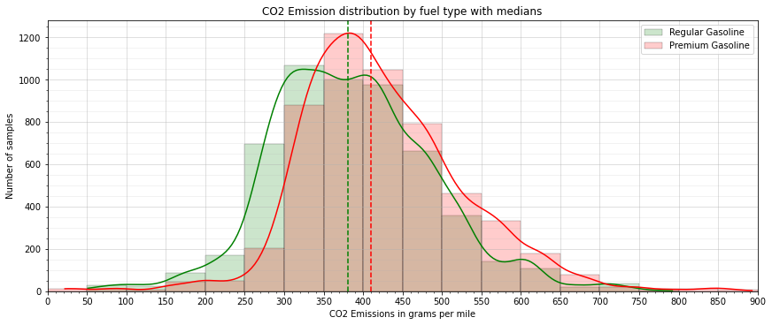

At first glance, watching the medians values showed by the dashed lines, we might hastily conclude that Premium gasoline is more polluting than Regular.

Is it possible that maybe those vehicles designed to run on Premium gasoline are also designed to be more performant and polluting than those meant for Regular gasoline?

In the graphs below, we clearly see that engines designed to run on Premium are also generally bigger in displacement and number of cylinders. We can see median displacement values of 2.5 and 3.0 litres and median numbers of cylinders of 4 and 6 as shown by the dashed lines.  
We can also see that Premium based engines tend to be supercharged and turbocharged more often than engines meant for Regular gasoline.

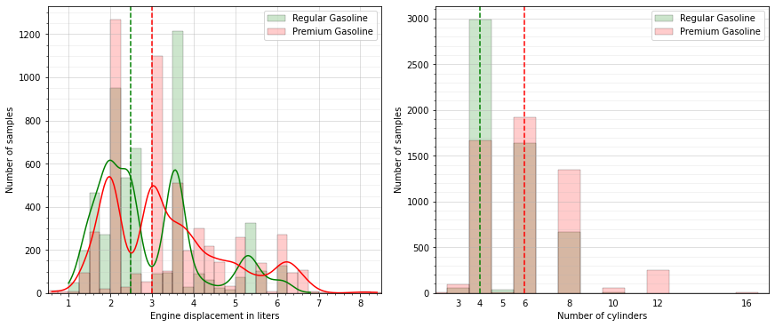

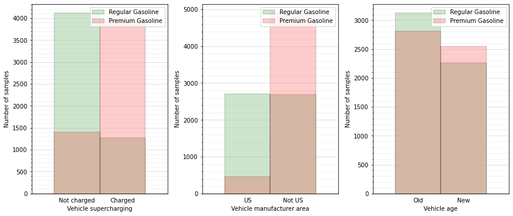

For our study case this is a concern because it means that we could have a biased sample in relation to our analysis goals.

Indeed we can easily find different studies on the web stating that:

- the larger the engine displacement, the higher the average fuel consumption and $CO_2$ emission
- the emission levels of $NO_x$, $CO_2$, and $CO_2$ are higher in terms of their concentration in the exhaust fume of the turbocharged engine, in comparison with the naturally aspirated engine
- there is a linear relationship between average fuel consumption and $CO_2$ emission of an automobile and its mass

A positive correlation between the aforementioned engines characteristics and $CO_2$ emissions is also clearly visible in the plots below for both Premium and Regular gasoline.

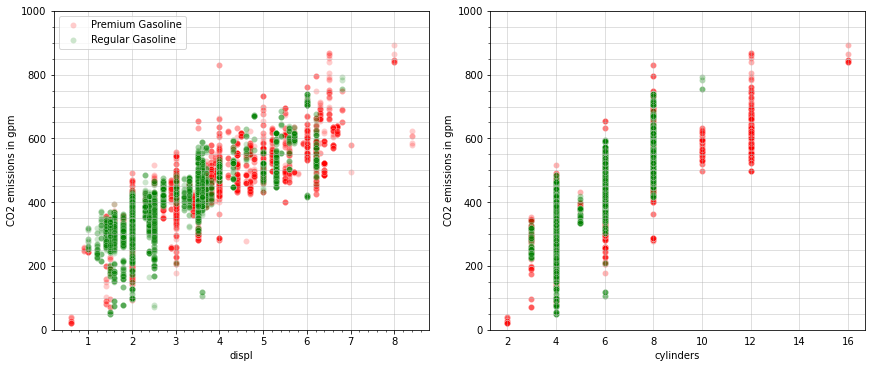

Now it's clear that we have a sampling bias in this scenario because the amount of $CO_2$ emissions is not only determined by the gasoline type that is on study, but also by confounders that impact differently on the two samples.  
In simple words, it's rather obvious that Premium gasoline will result being more pollutant than regular Gasoline if our test is based on a Regular gasoline 2.5 litres aspirated compact car versus a Premium gasoline 3.0 litres turbocharged SUV!

To allow us to draw our conclusions we need to minimize the effect of the confounding variables and, we think, the best way to do it in this scenario is by **"matching"**.  
With matching, we select two groups so that each member of the first group should have a counterpart in the second group with **the same values of potential confounders**, but different independent variable values (in this case, Premium and Regular gasoline).

Without further ado, we will match the groups defined by the independent variable "fuelType1" on these clear and potential confounders:

- vehicle class
- drive system
- engine displacement
- engine cylinders
- engine charger
- manufacturer area
- model age

To do so we set up an algorithm that:

1. groups the dataset by all the confounders,
2. drops all vehicles that are not in groups containing at least 3 units of either Premium and Regular gasoline,
3. if a group has not an equal number of Premium and Regular vehicles, **randomly** removes those in excess until parity is achieved,
4. finally create a test dataset with the remaining veichles.

We finally obtain a test dataset with an equal number of Premium and Regular gasoline models and an equal distribution of confounders between the two fuel types values.

Below we find a report of this series of tasks and a view of the test dataset grouping for an entire vehicle class.

```
-------------------------------------------------------------------------------------------
Independent variable value 1: Premium Gasoline
Independent variable value 2: Regular Gasoline
Dependent variable: co2TailpipeGpm
-------------------------------------------------------------------------------------------
Confounding variables to group by: ['VClass', 'drive', 'displ', 'cylinders', 'charger', 'area', 'age']
Number of groups formed: 1146
Number of groups that contain both a minimum of 3 samples for each Premium Gasoline and Regular Gasoline: 54
Number of samples in matched groups: 1629
Total samples in excess removed from all groups = 727
Final number of samples in the matched groups = 902
-------------------------------------------------------------------------------------------
```

| VClass | drive | displ | cylinders | charger | area | age | fuelType1 | N° of models |
| --- | --- | --- | --- | --- | --- | --- | --- | --- |
| Compact Cars | All-Wheel Drive | 2.0 | 4.0 | Charged | Not US | New | Premium Gasoline | 4 |
|  |  |  |  |  |  |  | Regular Gasoline | 4 |
|  |  |  |  |  |  | Old | Premium Gasoline | 3 |
|  |  |  |  |  |  |  | Regular Gasoline | 3 |
|  |  | 3.0 | 6.0 | Charged | Not US | Old | Premium Gasoline | 6 |
|  |  |  |  |  |  |  | Regular Gasoline | 6 |
|  | Front-Wheel Drive | 1.4 | 4.0 | Charged | Not US | Old | Premium Gasoline | 4 |
|  |  |  |  |  |  |  | Regular Gasoline | 4 |
|  |  | 1.5 | 4.0 | Charged | Not US | New | Premium Gasoline | 3 |
|  |  |  |  |  |  |  | Regular Gasoline | 3 |
|  |  | 1.6 | 4.0 | Charged | Not US | Old | Premium Gasoline | 16 |
|  |  |  |  |  |  |  | Regular Gasoline | 16 |
|  |  |  |  | Not charged | Not US | Old | Premium Gasoline | 16 |
|  |  |  |  |  |  |  | Regular Gasoline | 16 |
|  |  | 2.0 | 4.0 | Charged | Not US | New | Premium Gasoline | 19 |
|  |  |  |  |  |  |  | Regular Gasoline | 19 |
|  |  |  |  |  |  | Old | Premium Gasoline | 16 |
|  |  |  |  |  |  |  | Regular Gasoline | 16 |
|  |  |  |  | Not charged | Not US | Old | Premium Gasoline | 3 |
|  |  |  |  |  |  |  | Regular Gasoline | 3 |
|  |  | 2.4 | 4.0 | Not charged | Not US | Old | Premium Gasoline | 13 |
|  |  |  |  |  |  |  | Regular Gasoline | 13 |
|  | Rear-Wheel Drive | 2.0 | 4.0 | Charged | US | Old | Premium Gasoline | 4 |
|  |  |  |  |  |  |  | Regular Gasoline | 4 |

To check if all worked properly, let's see now how the already seen confounding variables distributions looks like using the matched test dataset.  
From the graphs below it seems all worked out properly. Indeed we se everywhere only brown bars, sign that all the previous red and green bars now are perfectly matching one above the other.

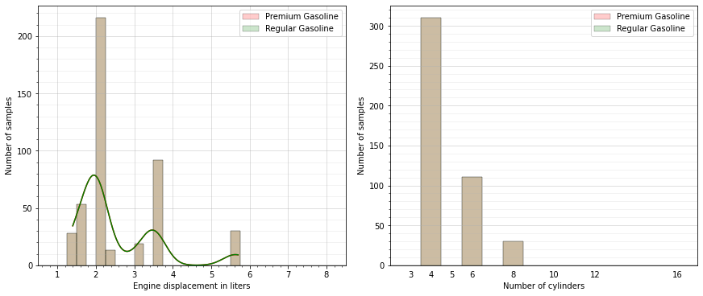

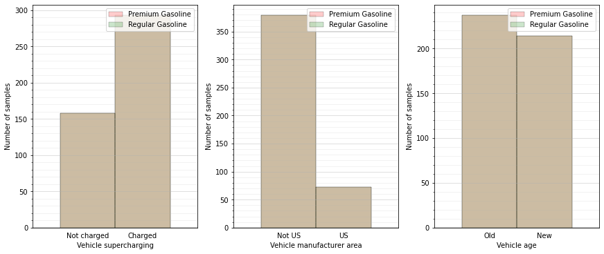

So, in this test dataset, the confounding variables distributions are now equivalent in both Premium and Regular models, as intended. Thus, if we will find now a difference in $CO_2$ emissions between Premium and Regular models, this will depends mainly on the different fuel type.

Finally, let's have again a look at the more interesting $CO_2$ emission distribution.  
Before matching, it seemed that Premium gasoline produced way more $CO_2$ emissions but now, looking at the histograms below, we can understand how much the confounding factors were effectively... confounding us!

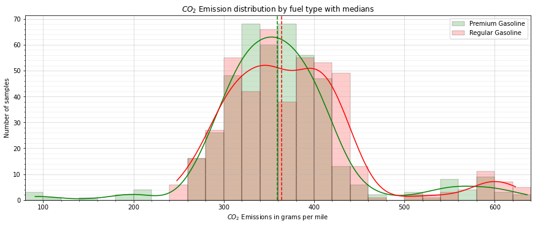

Inspecting the distributions, it seems that there is not so much difference in $CO_2$ emissions from Premium and Regular gasoline.

At this point, we have a perfectly matched test dataset with almost no biasing effect due to confounders and we are ready to go through the significance test process.

Nevertheless, we want to analyze first the other two questions and prepare the relative test datasets, to obtain proper answers.

### *4.2 US and not US manufacturer $CO_2$ emissions analysis*

To compare $CO_2$ emissions from models designed by US and non US manufacturers we will take into account also the design choices that differentiates the two groups.  
Basically, we will judge also on more or less ecological design choices like, for example, the major use of electric and low displacement engines or the less use of supercharged and turbo charged veichles.

In this case we will consider as confounders only the vehicle class, the wheels drive and the model age and thus we will ensure that our test dataset will have an equal distribution for those variables in both "US" and "not US" groups.

Below, we have a report on the outcome about the application of our matching algorithm and a view of the test dataset grouping for an entire vehicle class.

```
-------------------------------------------------------------------------------------------
Independent variable value 1: Not US
Independent variable value 2: US
Dependent variable: co2TailpipeGpm_comb
-------------------------------------------------------------------------------------------
Confounding variables to group by: ['VClass', 'drive', 'age']
Number of groups formed: 123
Number of groups that contain both a minimum of 3 samples for each Not US and US: 59
Number of samples in matched groups: 9691
Total samples in excess removed from all groups = 4617
Final number of samples in the matched groups = 5074
-------------------------------------------------------------------------------------------
```

| VClass | drive | age | area | N° of models |
| --- | --- | --- | --- | --- |
| Compact Cars | All-Wheel Drive | New | Not US | 10 |
|  |  |  | US | 10 |
|  |  | Old | Not US | 11 |
|  |  |  | US | 11 |
|  | Front-Wheel Drive | New | Not US | 26 |
|  |  |  | US | 26 |
|  |  | Old | Not US | 106 |
|  |  |  | US | 106 |
|  | Rear-Wheel Drive | New | Not US | 15 |
|  |  |  | US | 15 |
|  |  | Old | Not US | 48 |
|  |  |  | US | 48 |

From the histograms below we can clearly see a difference in the CO2 emissions of these groups that might lead us to think US models are really more polluting than non US models, given same model class, wheels drive and age.

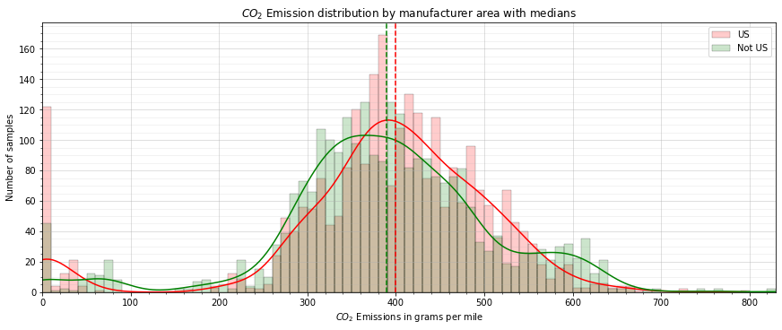

Indeed we can see a sensible difference in medians positions.  
Also, on the left side of those values, so in the region of lower CO2 emissions values, it looks like 'Not US' models are more abundant while the opposite looks to happen on the right side.

It will be a statistically significant difference? We will check this later, lets look now into "New" and "Old" models.

### *4.3 New and Old vehicles $CO_2$ emissions analysis*

To compare CO2 emissions from new models designs and old ones, again, we will take into account also the design choices that differentiates the two groups.

Also in this case, we will consider as confounders the vehicle class and the wheels drive. Since we saw a difference in models form US manufacturers and not, we will add also the manufacturer area as a potential confounder. Again, we will apply our matching algorithm to ensure that our test dataset have an equal distribution for those variables in both "New" and "Old" groups, and below we can see the report of the matching process.

```
-------------------------------------------------------------------------------------------
Independent variable value 1: New
Independent variable value 2: Old
Dependent variable: co2TailpipeGpm_comb
-------------------------------------------------------------------------------------------
Confounding variables to group by: ['VClass', 'drive', 'area']
Number of groups formed: 102
Number of groups that contain both a minimum of 3 samples for each New and Old: 80
Number of samples in matched groups: 11199
Total samples in excess removed from all groups = 2031
Final number of samples in the matched groups = 9168
-------------------------------------------------------------------------------------------
```

Here is a view of the test dataset grouping for an entire vehicle class.

| VClass | drive | area | age | N° of models |
| --- | --- | --- | --- | --- |
| Compact Cars | 4-Wheel Drive | Not US | New | 44 |
|  |  |  | Old | 44 |
|  | All-Wheel Drive | Not US | New | 120 |
|  |  |  | Old | 120 |
|  |  | US | New | 10 |
|  |  |  | Old | 10 |
|  | Front-Wheel Drive | Not US | New | 209 |
|  |  |  | Old | 209 |
|  |  | US | New | 26 |
|  |  |  | Old | 26 |
|  | Rear-Wheel Drive | Not US | New | 117 |
|  |  |  | Old | 117 |
|  |  | US | New | 15 |
|  |  |  | Old | 15 |

Since it is common opinion that vehicles producers are putting more and more effort toward the development of more ecological models, it is somewhat unexpected what we see in the histograms below.

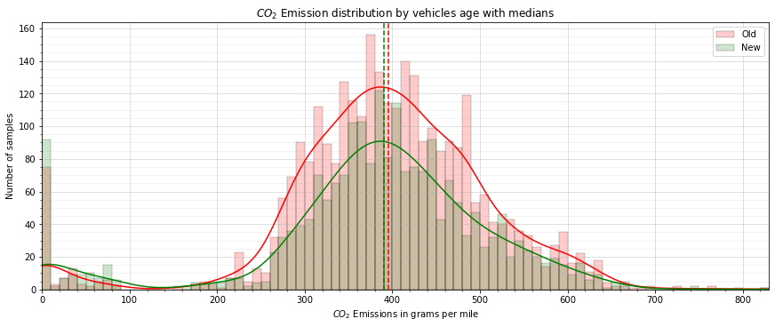

## 5. Hypothesis formulation and significance test

Now is time to formulate some hypothesis based on the insights we've gathered so far.

Summarizing, we wanted to look evidence about differences $CO_2$ emissions based on:

- type of primary fuel, either Premium or Regular gasoline,
- manufacturer area, either US or not US,
- models ages, either older, so from 2013 to 2017 included, or newer.

The insights we've drawn watching the previous distributions are that:

- $CO_2$ emissions from Premium gasoline seem to be slightly less than those from Regular gasoline,
- the models designed by US manufacturers seem to be more polluting than those designed by non US ones,
- $CO_2$ emissions from new models seem to be slightly less than those from old models,

Let's now go through significance testing process case by case.

### *5.1 'Regular' and 'Premium' gasoline $CO_2$ emissions*

First of all we have to check the two distributions for normality and, looking at the previous histograms, it seems that this is not the case.  
To confirm our foreseas, we will test both distributions with the Shapiro-Wilk test.

The Shapiro–Wilk test is a test of normality in frequentist statistics. It was published in 1965 by Samuel Sanford Shapiro and Martin Wilk. $H_{0}$ of this test is that the population is normally distributed. Thus, if the p-value is less than the chosen significance level $\alpha$, then $H_{0}$ is rejected and there is evidence that the data tested are not normally distributed. On the other hand, if the p-value is greater than the chosen $\alpha$ level, then $H_{0}$ can not be rejected, so there is statistical evidence that data came from a normally distributed population.

Below we find the test results with $\alpha$ = 0.05.

```
-------------------------------------------------------------------------------------------
Group = Premium Gasoline
Data to check distribution = co2TailpipeGpm
Number of samples = 451
Significance level = 0.05
-------------------------------------------------------------------------------------------
*** Shapiro-Wilk normality test ***
Ho: "co2TailpipeGpm" data from group "Premium Gasoline" ARE drawn from a normal distributions
Ha: "co2TailpipeGpm" data from group "Premium Gasoline" ARE NOT drawn from a normal distributions
p-value = 0.000000
Outcome: We reject the null hypothesis, data ARE NOT normally distributed
-------------------------------------------------------------------------------------------
Group = Regular Gasoline
Data to check distribution = co2TailpipeGpm
Number of samples = 451
Significance level = 0.05
-------------------------------------------------------------------------------------------
*** Shapiro-Wilk normality test ***
Ho: "co2TailpipeGpm" data from group "Regular Gasoline" ARE drawn from a normal distributions
Ha: "co2TailpipeGpm" data from group "Regular Gasoline" ARE NOT drawn from a normal distributions
p-value = 0.000000
Outcome: We reject the null hypothesis, data ARE NOT normally distributed
-------------------------------------------------------------------------------------------
```

The Shapiro-Wilk test strongly confirms that we are far away from normal distributions and suggests us to rely on non parametric statistical tests.

Given this and considering that we've decided to retain possible outlier values, we choose to test significance with the Mann–Whitney U test.

The Mann–Whitney U test (also called the Mann–Whitney–Wilcoxon (MWW), Wilcoxon rank-sum test, or Wilcoxon–Mann–Whitney test) is a a ranks based and non parametric test to compare two independant samples on the $H_{0}$ that they are drawn from two populations stochastically equivalent. This means that for randomly selected values X and Y from both populations, the probability of X being greater than Y is equal to the probability of Y being greater than X. Consequently, $H_{A}$ is that one population is stochastically greater than the other, thus the probability of X being greater than Y is not equal to the probability of Y being greater than X.

The Mann–Whitney U test is commonly used instead of the two independent samples t-test when data are not normally distributed.

Being a ranks based test, it is robust to outliers presence. This is because, when the data are ranked, an outlier will simply be recognized as a case that is ranked one above or below the next less extreme case. So the effective value of the difference does not affect the test.

Below we find the outcome of the significance test with $\alpha$ = 0.05.

```
-------------------------------------------------------------------------------------------
Sample N°1 = co2TailpipeGpm data from Premium Gasoline group
Sample N°2 = co2TailpipeGpm data from Regular Gasoline group
Sample dimensions = 451 vs 451
-------------------------------------------------------------------------------------------
*** Hypothesis testing with Mann-Whitney U-test ***
Ho: Premium Gasoline group distribution is stochastically EQUIVALENT OR GREATER than Regular Gasoline distribution
Ha: Premium Gasoline group distribution is stochastically LESSER than Regular Gasoline distribution
Significance level = 0.05
U = 93032
p-value = 0.013353
-------------------------------------------------------------------------------------------
*** Outcome ***
We reject the null hypothesis and accept the alternative hypothesis:
Premium Gasoline group distribution is stochastically LESSER than Regular Gasoline distribution
-------------------------------------------------------------------------------------------
```

The Mann–Whitney U test confirms our previous insight, so we have a statistical evidence that **gasoline type affects vehicles $CO_2$ emissions and Premium one is less polluting than Regular one**.

### *5.2 'US' and 'not US' vehicles models $CO_2$ emissions*

Since we have seen a difference in medians values with 'US' models seeming to be more polluting than 'non US' models, in this case, we will test the $H_{0}$ that $CO_2$ emissions distribution in 'Not US' group is stochastically equivalent or greater than that in 'US' group. Consequently the $H_{A}$ will be that $CO_2$ emissions distribution in 'Not US' group is stochastically lesser than that in 'US' group. So this will be a one sided test.

Also in this case, the distributions don't seem to be normal and below we find the Shapiro-Wilk normality test results with $\alpha$ = 0.05.

```
-------------------------------------------------------------------------------------------
Group = Not US
Data to check distribution = co2TailpipeGpm_comb
Number of samples = 2537
Significance level = 0.05
-------------------------------------------------------------------------------------------
*** Shapiro-Wilk normality test ***
Ho: "co2TailpipeGpm_comb" data from group "Not US" ARE drawn from a normal distributions
Ha: "co2TailpipeGpm_comb" data from group "Not US" ARE NOT drawn from a normal distributions
p-value = 0.000000
Outcome: We reject the null hypothesis, data ARE NOT normally distributed
-------------------------------------------------------------------------------------------
Group = US
Data to check distribution = co2TailpipeGpm_comb
Number of samples = 2537
Significance level = 0.05
-------------------------------------------------------------------------------------------
*** Shapiro-Wilk normality test ***
Ho: "co2TailpipeGpm_comb" data from group "US" ARE drawn from a normal distributions
Ha: "co2TailpipeGpm_comb" data from group "US" ARE NOT drawn from a normal distributions
p-value = 0.000000
Outcome: We reject the null hypothesis, data ARE NOT normally distributed
-------------------------------------------------------------------------------------------
```

Since non normality is verified, we perform again a significance test with Mann-Whitney U-test.  
Below the result with $\alpha$ = 0.05.

```
-------------------------------------------------------------------------------------------
Sample N°1 = co2TailpipeGpm_comb data from Not US group
Sample N°2 = co2TailpipeGpm_comb data from US group
Sample dimensions = 2537 vs 2537
-------------------------------------------------------------------------------------------
*** Hypothesis testing with Mann-Whitney U-test ***
Ho: Not US group distribution is stochastically EQUIVALENT OR GREATER than US distribution
Ha: Not US group distribution is stochastically LESSER than US distribution
Significance level = 0.05
U = 3046290
p-value = 0.000493
-------------------------------------------------------------------------------------------
*** Outcome ***
We reject the null hypothesis and accept the alternative hypothesis:
Not US group distribution is stochastically LESSER than US distribution
-------------------------------------------------------------------------------------------
```

Again, the Mann – Whitney U test confirms our previous insight so we can state with statistical evidence that **manufacturer area affects the models $CO_2$ emissions and non US models are less polluting than US models**, given the same vehicle class, wheels drive and age.

### *5.3 'New' and 'Old' vehicles models $CO_2$ emissions*

Since we have seen similar distributions and a small difference between medians values, with 'New' models seeming to be amost as polluting as 'Old' models, in this case we will test the $H_{0}$ that $CO_2$ emissions distribution in 'New' group is stochastically equivalent than that in 'Old' group. Consequently the $H_{A}$ will be that they are not equivalent, so this will be a two sided test.

Again, the distributions don't seem to be normal and below we find the Shapiro-Wilk normality test results with $\alpha$ = 0.05.

```
-------------------------------------------------------------------------------------------
Group = New
Data to check distribution = co2TailpipeGpm_comb
Number of samples = 4584
Significance level = 0.05
-------------------------------------------------------------------------------------------
*** Shapiro-Wilk normality test ***
Ho: "co2TailpipeGpm_comb" data from group "New" ARE drawn from a normal distributions
Ha: "co2TailpipeGpm_comb" data from group "New" ARE NOT drawn from a normal distributions
p-value = 0.000000
Outcome: We reject the null hypothesis, data ARE NOT normally distributed
-------------------------------------------------------------------------------------------
Group = Old
Data to check distribution = co2TailpipeGpm_comb
Number of samples = 4584
Significance level = 0.05
-------------------------------------------------------------------------------------------
*** Shapiro-Wilk normality test ***
Ho: "co2TailpipeGpm_comb" data from group "Old" ARE drawn from a normal distributions
Ha: "co2TailpipeGpm_comb" data from group "Old" ARE NOT drawn from a normal distributions
p-value = 0.000000
Outcome: We reject the null hypothesis, data ARE NOT normally distributed
-------------------------------------------------------------------------------------------
```

Non normality is confirmed and we perform again a significance test with Mann-Whitney U-test with $\alpha$ = 0.05.  
Below we find the outcome.

```
-------------------------------------------------------------------------------------------
Sample N°1 = co2TailpipeGpm_comb data from New group
Sample N°2 = co2TailpipeGpm_comb data from Old group
Sample dimensions = 4584 vs 4584
-------------------------------------------------------------------------------------------
*** Hypothesis testing with Mann-Whitney U-test ***
Ho: New group distribution is stochastically EQUIVALENT to Old distribution
Ha: New group distribution is stochastically NOT EQUIVALENT to Old distribution
Significance level = 0.05
U = 9222484
p-value = 0.000000
-------------------------------------------------------------------------------------------
*** Outcome ***
We reject the null hypothesis and accept the alternative hypothesis:
New group distribution is stochastically NOT EQUIVALENT to Old distribution
-------------------------------------------------------------------------------------------
```

What we see here is somewhat unexpected because the significance test strongly suggests that they are not stochastically equivalent.

At this point we want to check which distribution is greater or lesser so we will run another significance test, one sided this time.  
We will test the $H_{0}$ that $CO_2$ emissions from group 'New' are stochastically equivalent or greater than those from group 'Old'. Consequently the $H_{A}$ will be that they are stochastically lesser.

Below we see the outcome of the one sided significance test with $\alpha$ = 0.05.

```
-------------------------------------------------------------------------------------------
Sample N°1 = co2TailpipeGpm_comb data from New group
Sample N°2 = co2TailpipeGpm_comb data from Old group
Sample dimensions = 4584 vs 4584
-------------------------------------------------------------------------------------------
*** Hypothesis testing with Mann-Whitney U-test ***
Ho: New group distribution is stochastically EQUIVALENT OR GREATER than Old distribution
Ha: New group distribution is stochastically LESSER than Old distribution
Significance level = 0.05
U = 9222484
p-value = 0.000000
-------------------------------------------------------------------------------------------
*** Outcome ***
We reject the null hypothesis and accept the alternative hypothesis:
New group distribution is stochastically LESSER than Old distribution
-------------------------------------------------------------------------------------------
```

Looking at the p-value, the one sided Mann – Whitney U test strongly confirms that we have a statistical evidence that **new models are less polluting than old models**.

## 6. Next steps in analyzing data

Looking at what we have found so far, we think there are two points we could study more deeply.

Relatively to the Premium and Regular gasoline, we have found evidences about a statistcal difference in $CO_2$ emissions from Premium and Regular gasoline.  
Nevertheless the p-value we calculate with the Mann-Whitney U-test was about 0.013, thus not so far from the significance level chosen (0.05). Also, as we remember, the testing dataset was produced using random sampling. Precisely on a total of 1629 samples, 727 were randomly removed to balance the number of Premium and Regular samples in each group.

Since we've sacrificed almost one half of the information to mitigate the effect of confounders, we want to check if the outcome is still valid putting back somehow the missing information.

Relatively to "New" and "Old" models, we saw how the Mann - Whitney U-test has strongly confirmed statistical significance even if the histograms didn't show a sensible difference. Thus, it will be interesting to further investigate this outcome.

### *6.1 Verifying that Premium gasoline is less polluting than Regular gasoline*

Then we will perform $N$ iterations of these tasks:

1. balances the number of Premium and Regular vehicles in each group by randomly removing those in excess,
2. performs a Mann Mann - Whitney U-test on the resulting dataset,
3. add the resultin p-value in a list.

Since we have multiple testing we need to account the fact that we could find small p-values < $\alpha$ just by pure chance.  
One of the most commonly used approaches to control familywise error rate (FWER) in multiple comparisons is the Bonferroni correction, but in this case we consider it to be too stringent. Instead, since we can consider this as an exploratory study, we will proceed by controlling false discovery rate (FDR).  
FDR controlling procedures provide less stringent control of Type I errors (false positives) compared to FWER controlling procedures (such as the Bonferroni correction), which control the probability of at least one Type I error. Thus, FDR-controlling procedures have greater power, at the cost of increased numbers of Type I errors.

So, after completing the $N$ iterations obtaining $N$ p-values, we will correct them using the Benjamini-Hochberg procedure to control the FDR at a level $\alpha$ = 0.05.

Below a report of the process and an histogram of the corrected p-values.

```
-------------------------------------------------------------------------------------------
Independent variable value 1: Premium Gasoline
Independent variable value 2: Regular Gasoline
Dependent variable: co2TailpipeGpm
-------------------------------------------------------------------------------------------
Confounding variables to group by: ['VClass', 'drive', 'displ', 'cylinders', 'charger', 'area', 'age']
Number of groups formed: 1146
Number of groups that contain both a minimum of 3 samples for each Premium Gasoline and Regular Gasoline: 54
Number of samples in matched groups: 1629
Number of samples labeled as Premium Gasoline: 896
Number of samples labeled as Regular Gasoline: 733
-------------------------------------------------------------------------------------------
*** Fuel types Monte Carlo simulation ***
N = 500
Simulation completed in 14.1 seconds.
-------------------------------------------------------------------------------------------
```

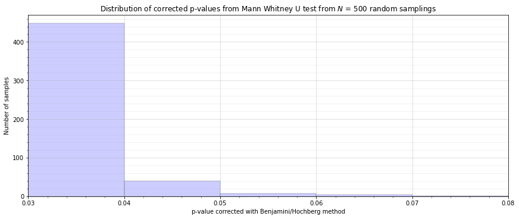

As we can see, almost every test report a corrected p-value < $\alpha$.

Finally, we can definitely reject the $H_0$ and conclude that there is statistical evidence that Premium gasoline is less polluting than Regular gasoline.

### *6.2 Verifying that new models are less polluting than old models*

During significance testing, as an outcome of the Mann - Whitney U-test, we obtained a statistical evidence that the distributions of the $CO_2$ emissions from 'New' models is stochastically lesser than that from 'Old' models. This was an unexpected outcome since the $CO_2$ emissions histograms of both groups were fairly similar and with almost same median values.

What we want to check now is that, if we choose randomly a sample from the 'New' group and one from the 'Old' group, the probability $p$ that the first is lesser than the second is effectively higher than the probability $(1-p)$ of the opposite scenario.

Given the dataset dimension, we can easily calculate $p$, simply confronting all the possible combinations of paired samples from both groups and counting how many times New models emissions are lesser than Old ones.

Below a report of the computation.

```
-------------------------------------------------------------------------------------------
Computation of 21013056 combinations started (4584 * 4584)
Computation completed in 5.1 seconds.
The probability that New models CO2 emissions are lesser than Old models is: 0.559
-------------------------------------------------------------------------------------------
```

Now, surely the random removing of samples to balance groups had an effect on the value of $p$. Thus, we will repeat the computation other $N$ times to see if we obtain consistent results.

```
-------------------------------------------------------------------------------------------
Independent variable value 1: New
Independent variable value 2: Old
Dependent variable: co2TailpipeGpm_comb
-------------------------------------------------------------------------------------------
Confounding variables to group by: ['VClass', 'drive', 'area']
Number of groups formed: 102
Number of groups that contain both a minimum of 3 samples for each New and Old: 80
Number of samples in matched groups: 11199
Number of samples labeled as New: 5084
Number of samples labeled as Old: 6115
-------------------------------------------------------------------------------------------
*** Model ages Monte Carlo simulation ***
N = 9
-------------------------------------------------------------------------------------------
Computation N = 1/9 started
2031 randomly removed to balance groups.
Computation of 21013056 (4584 * 4584) combinations started
Computation of combinations completed
The probability that New models CO2 emissions are lesser than Old models is: 0.562
-------------------------------------------------------------------------------------------
Computation N = 2/9 started
2031 randomly removed to balance groups.
Computation of 21013056 (4584 * 4584) combinations started
Computation of combinations completed
The probability that New models CO2 emissions are lesser than Old models is: 0.556
-------------------------------------------------------------------------------------------
Computation N = 3/9 started
2031 randomly removed to balance groups.
Computation of 21013056 (4584 * 4584) combinations started
Computation of combinations completed
The probability that New models CO2 emissions are lesser than Old models is: 0.560
-------------------------------------------------------------------------------------------
Computation N = 4/9 started
2031 randomly removed to balance groups.
Computation of 21013056 (4584 * 4584) combinations started
Computation of combinations completed
The probability that New models CO2 emissions are lesser than Old models is: 0.557
-------------------------------------------------------------------------------------------
Computation N = 5/9 started
```

[output cut: 19 more lines]

```
Computation of 21013056 (4584 * 4584) combinations started
Computation of combinations completed
The probability that New models CO2 emissions are lesser than Old models is: 0.555
-------------------------------------------------------------------------------------------
Computation N = 9/9 started
2031 randomly removed to balance groups.
Computation of 21013056 (4584 * 4584) combinations started
Computation of combinations completed
The probability that New models CO2 emissions are lesser than Old models is: 0.556
-------------------------------------------------------------------------------------------
All computations completed in 46.0 seconds.
Total number of p valuated = 10
Mean of p = 0.55779
St.Deviation of p = 0.00231
-------------------------------------------------------------------------------------------
```

As we can see from the computation report, performing $N$ resamples produce consistent results. Finally we can say that the probability that a 'New' model is less polluting than an 'Old' is $p \approx 0.557$, thus confirming the outcome of our previous tests.

## 7. Quality of the data

We have acquired data from https://www.fueleconomy.gov/ which is the official U.S. government source for fuel economy information. This website is administered by Oak Ridge National Laboratory for the U.S. Department of Energy and the U.S. Environmental Protection Agency.  
About emissions testing, data is derived from vehicle testing done at National Vehicle and Fuel Emissions Laboratory and by vehicle manufacturers who submit their own test data to EPA for verification.

All new cars and trucks sold in the U.S. must be certified to meet federal emission standards, such as limits on the amount of smog-forming and greenhouse gas emissions that they can produce. Most testing is performed by auto manufacturers at their own facilities. EPA then audits the data and performs its own testing on some of the vehicles to confirm the manufacturers' results.  
Below a description of the testing process:

1. The vehicle is tested in a dynamometer test cell, which works like a treadmill for cars.
2. A driver operates the vehicle following driving "schedules," which simulate typical trips (including specific speeds and acceleration, different temperatures, use of A/C, etc).
3. A hose is connected to the tailpipe to collect engine exhaust. Carbon is measured to calculate the amount of fuel burned. Other air pollutants are measured using gas analyzers, and fine particles (particulate matter, PM) are weighed in a special "clean room" (some of these methods will differ for alternative-fueled vehicles, such as electric vehicles).

Other than vehicle emission certification, the same dataset is also used by:

- the U.S. Department of Energy (DOE) to publish the annual **Fuel Economy Guide**,
- the U.S. Department of Transportation (DOT) to administer the Corporate Average Fuel Economy (CAFE) program,
- the Internal Revenue Service (IRS) to collect "Gas Guzzler" taxes.

As a consequence of the above, the dataset it's very reliable and our choice to retain outliers is well justified.

Unfortunately the dataset does not contain information about the vehicles mass and the engine power that would have been ideal for a deeper comparison between $CO_2$ emissions from similar mass / power samples.